← HomeJASP Student Developers Group

SESSION 02

Learn · Build · Explore

# From Button to Output

Wire your first control all the way to R

Leo Liu · Thu 26 Nov · 11:30–13:00 · REC JKK.26 · Bring your laptop

# Session 2: From Button to Output

📍 Jump to where we stopped

## Previously… 📺 ⏱ 5 min 0:00–0:05

*Previously, on JASP Student Developers…* Before you peek: can you still answer these? **Think first, then click.**

## Welcome back! ⏱ 5 min 0:05–0:10

Last time we stopped right after your first menu edit. Today we pick up from there, and go all the way from a **button** to **R**.

🎯 **Today's win:** you tick your own button, and R answers.

🐛 Warm up**→**👯 Detectives**→**🎮 Predict the window**→**☑️ Button**→**🔄 Behind the scenes**→**🧠 R**→**🔮 Predict**→**🔧 Fix

👆 Click a step to jump there

Quick check before we start:

- 📊 RStudio: `jaspDataWrangling.Rproj` is open (the Console says *Project … loaded*)
- 🧮 JASP: **Dev: Data Wrangling → Missing Values** opens

**😶‍🌫️ Missed Session 1, or your module is broken?**

No problem! Start from a fresh copy:

1. ⬇️ Download the module and unzip it.
2. Follow Install the module and Load it in JASP from Session 1.
3. Raise your hand if anything gets stuck. We’ll sort it out together.

## Warm-up: bug hunt 🐛 ⏱ 10 min 0:10–0:20

Last time, you edited the menu in `inst/Description.qml`. Let’s see how sharp your eyes are now.

Something went wrong in `Description.qml`… five times. Read the symptom, then **click the line you think is broken**.

🐛 0 / 5 squashedTip: in real life, compare with a version that works. Bugs hide in tiny details!

## Pair up: QML detectives 👯 ⏱ 10 min 0:20–0:30

### 🧭 From the menu to the window

In the bug hunt you read `Description.qml`: the **menu**. But what happens when you *click* **Control Playground** in that menu? Look at its `Analysis` block again: **which line tells JASP which window to open?**

**🔍 Check your answer**

`qml : "controlPlayground.qml"`. Click the menu item, and JASP opens `inst/qml/controlPlayground.qml`: the window with all the controls. (And `func`? That one points to R. Later today!)

📋

**Description.qml**Menu✅ Session 1

→

🎛️

**controlPlayground.qml**Window👉 Now

→

📊

**controlPlayground.R**Computation⏳ Later today

Every window file has the same shape: a `Form`, with the controls inside it.

```
import JASP.Controls          // the box of building blocks

Form                          // the whole window
{
    info: qsTr("…")           // 🔍 detective mission #1!

    TextField                 // one control…
    {
        name : "yourName"     // the name R uses (more on that later today)
        label: qsTr("Your name")
    }

    // …more controls…
}
```

**Now read the real thing.** Work with your neighbour: **one of you opens the QML file, the other opens JASP.** Then solve these missions together, switching roles whenever you like:

🕵️**Code**📊 RStudio · `inst/qml/controlPlayground.qml`

⇄

🧭**JASP**🧮 Control Playground

The first four: just look. The last two: **predict first**, then edit and check in JASP (the edit loop from 📺 *Previously*).

- **The welcome note.** Near the top of the file is a line starting with `info:`. Where does that text appear in JASP?
- **Ticked from the start.** Which boxes are already ticked when the window opens? Find the line that makes each one ticked.
- **The grey one.** Untick “Show histogram”. What happens to “Mark the mean”? Find the reason in the code.
- **The hidden drawer.** Some options are hidden when the window opens. Find them in JASP, and find what hides them in the code.
- **Wider box.** The *Your name* field has `fieldWidth: 160`. Change it to `300`. What happens?
- **Over the limit.** Type `20000` as *Sample size* in JASP. What happens? Change the code so `20000` is allowed.

**🔍 Reveal the answers (after you've tried!)**

`info` is the help text behind the ⓘ button. Ticked at start: “Show histogram”, “Teal” and “Show what R received”, each with `checked: true`. Untick “Show histogram” and “Mark the mean” turns grey: it sits *inside* the “Show histogram” CheckBox, so it only works while its parent is ticked. The drawer is a `Section`. The name box gets wider. JASP won’t accept 20000 because of `max: 10000`: raise it to e.g. `max: 50000`.

## Read the QML, predict the window 🎮 ⏱ 5 min 0:30–0:35

One more detective skill before you build: read QML **without** JASP open, and picture the window in your head.

INTERACTIVE · 3 MINI CHALLENGES

#### Read it. Predict it. Reveal it.

Read a few lines of QML, then predict what shows up in the JASP window.

**0 / 3**solved

📄 THE QMLREAD THIS

🪟 JASP WINDOW

🧠 YOUR PREDICTIONTHINK FIRST

🔗 **Remember:** `label` is what users see · `name` is what R uses (more on that later today)

Teaching simulation only: the mini window imitates JASP; it doesn't run JASP. Check your answers for real in Control Playground.

🧰 Curious what else is in the toolbox? Every control, live and clickable: see the control gallery in the Appendix →

## Add your first button ☑️ ⏱ 10 min 0:35–0:45

Time to build in **your own** window: **Missing Values**. Open `inst/qml/missingValues.qml`, look at the target picture, and rebuild it. Today it won’t just *look* right: by the end of the session, it will talk to R.

**⭐ A first question**

*The Calm Minds team opens their data file and asks the obvious question: “How much of this is missing?” Before any numbers, they need a way to ask for them.*

**Build this:**

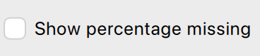

**💡 Hint 1**

You have seen a control exactly like this today. Where?

**💡 Hint 2**

Borrow it from `controlPlayground.qml`, change one thing, and paste it inside `Form { }`, below the Variables box.

- My checkbox shows up in Missing Values

## Behind the scenes 🔄 ⏱ 15 min 0:45–1:00

Your checkbox is in the window. But what happens **behind the scenes** when you click it? Time to open the third file: `R/missingValues.R`. Let’s read it together.

### 🧰 One function, three parts

Find this line:

```r
missingValues <- function(jaspResults, dataset, options)
```

This is the function JASP runs for **Missing Values**. It gets three things:

🎛️

`options`**What the user clicked**Comes *in* from the window on the left

🗂️

`dataset`**The data**Comes *in* from the data file  
⏳ Session 3

📥

`jaspResults`**The shelf**Every box you put on it shows up on the *right*

🎛️ Left: the window

☑️ Show percentage missing

▤ Variables

options

🧠 `missingValues()`

↑

🗂️ `dataset`Session 3

jaspResults

📥 Right: the shelf

*[["welcome"]]***Under construction**

*[["optionsSeen"]]***What R received**

📦**New idea****jaspResults is a shelf of boxes**

Picture `jaspResults` as a **shelf**. Everything you see on the right side of JASP is a **box** on that shelf, and every box has a **label**, like `[["welcome"]]`.

📦 A **new** label → a new box on the shelf. 🔄 The **same** label → the old box is swapped for the new one.

We’ll keep coming back to this shelf today.

### 📖 Take it apart

Inside the function, the first thing it does is make the *Under construction* note you see in JASP. **Click each coloured part** to see what it does.

"Under construction", "This analysis doesn't compute anything yet. …"

👆 Click a coloured part of the code.

**💬 Wait… `options$showPercentage` but `jaspResults[["welcome"]]`? `$` or `[[ ]]`?**

Both pick **one thing by its name** out of a list:

| You write | It means |
| --- | --- |
| `options$showPercentage` | the item called `showPercentage` |
| `options[["showPercentage"]]` | exactly the same item: the name is just in quotes |
| `jaspResults[["welcome"]]` | the box labelled `welcome` on the shelf |

💡 **Rule of thumb for today:** read options with `$`, put boxes on the shelf with `[[" "]]`. The shelf is a special JASP object, so always use `[[" "]]` there.

**Check yourself**, then peek:

**1️⃣ You want the heading to say “Hello!”. Which part do you change?**

The text after `title =`: `title = "Hello!"`.

**2️⃣ How many blocks do you see on the right side of JASP? Find the line in `missingValues.R` that makes each one.**

Two blocks, two labels: `[["welcome"]]` makes *Under construction*, and `[["optionsSeen"]]` makes *What R received*.

**3️⃣ Two pieces of output use the same label. What happens?**

The second box is **swapped in** for the first: one label, one box. Keep that in mind for the next experiment…

📍

**We stopped here**Thu 26 Nov · next time we’ll pick up from the clock experiment (⏱️ *R was here*) together

### ⏱️ R was here: when does R run?

You click a checkbox in JASP. What does R do? **Decide first:**

**The experiment:** give R a clock. You can read it now: same shape as the welcome note. Paste this into `R/missingValues.R`, inside the function, just above `return()`:

```r
jaspResults[["clock"]] <- createJaspHtml(
  title = "R was here",
  text  = format(Sys.time(), "%H:%M:%S")
)
```

Now tick, untick, wait a few seconds, tick again… and keep an eye on the clock. ⏱️

**🤔 So, when does R run? (after you’ve tried!)**

The clock jumps after **every** click. Every time you change anything in the window, JASP sends *all* the options to R, and R runs the **whole** function again, from the first line to `return()`:

👆 You change a control**→**📦 QML packs all options by `name`**→**📨 JASP sends them to R**→**🔁 R runs the whole function**→**📦 Boxes go on the shelf**↺**

Try it in slow motion below.

A mini JASP in slow motion. Tick and untick the checkbox, and watch the log: R runs **all** the lines, every time. Same labels → the boxes are swapped, so the clock is always new.

🎛️ The window Show percentage missingoptions$showPercentage = **FALSE**

🧠 missingValues.R

📥 The shelf: jaspResults

1. 👆 Tick the checkbox to change an option…

🧩 **Keep this in mind:** the clock is new after every click. Is *all* output new after every click? We’ll find out soon…

- I can name the three parts, and where each one shows up in JASP
- My clock shows the time, and I know when R runs

## Your first R code 🧠 ⏱ 15 min 1:00–1:15

Your turn to write R, in two small steps.

### ✍️ Step 1: put your own box on the shelf

🎯 Your goal: this box in the JASP output

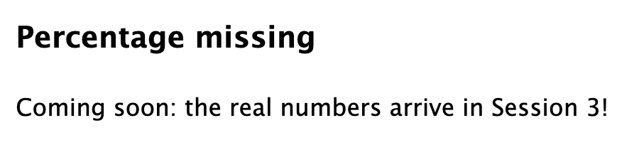

Use the same shape as the welcome note. This time we do it in **two moves**: first *make* the box, then *put it on the shelf*. (You’ll see why that’s handy later.) Fill in the blanks, and paste it inside the function, just above `return()`:

```r
note <- createJaspHtml(
  title = "________",
  text  = "________"
)
jaspResults[["________"]] <- note
```

**💡 Hint**

`title` and `text` are just text: write anything you like, in quotes. The last blank is the label for your box: a short name in quotes that no other box on the shelf uses.

**🔓 Still stuck? Show the answer**

```
note <- createJaspHtml(
  title = "Percentage missing",
  text  = "Coming soon: the real numbers arrive in Session 3!"
)
jaspResults[["percentage"]] <- note
```

Now tick and untick your checkbox. Your box is always there, just like the clock.

### 🤔 Wait… what if I *don’t* want it every time?

Your box shows up after every click, because R makes it in every run. But this box should only appear when the user **asks** for it: that’s what your checkbox is for! So, how does R know whether it’s ticked? Look at the output in JASP: the table **What R received**.

🌉**New idea****The name is the bridge**

The `name` you gave your CheckBox in QML is how R finds it:

```
CheckBox { name: "showPercentage"; … }   →   options$showPercentage
```

Remember `d$Age` from R Puzzles? `options` is a list too, and `$` picks one thing out of it. A ticked box arrives as `TRUE`, an unticked one as `FALSE`.

### 🔀 Step 2: only when the checkbox is ticked

In R, “only when…” is spelled `if`. Wrap your box in it: you only add **two lines**, one above and one below.

```r
if (options$________) {              # ⬅ new
  note <- createJaspHtml(
    title = "Percentage missing",
    text  = "Coming soon: the real numbers arrive in Session 3!"
  )
  jaspResults[["percentage"]] <- note
}                                     # ⬅ new
```

**💡 Hint**

The blank: you just met it in *What R received*.

**🔓 Still stuck? Show the answer**

```
if (options$showPercentage) {
  note <- createJaspHtml(
    title = "Percentage missing",
    text  = "Coming soon: the real numbers arrive in Session 3!"
  )
  jaspResults[["percentage"]] <- note
}
```

- My own box shows up in JASP
- I found my checkbox in *What R received*: `TRUE` when ticked, `FALSE` when not
- Ticking the checkbox shows my box

## Predict, then try 🔮 ⏱ 5 min 1:15–1:20

Your note is on screen. Now you **untick** the box. What happens to the note? **Decide first**, then try it in JASP.

**🤔 What happened, and why? (after you’ve tried!)**

The note **stays**, even though the checkbox is unticked and your `if` is now `FALSE`.

Think of the shelf. JASP **keeps the shelf** from one run to the next, so it doesn’t have to rebuild everything after every click. R only *adds* or *swaps* boxes. The clock is swapped every run, so it’s always new. But once the checkbox is unticked, your `if` skips the note: nobody swaps it, nobody removes it. The old box is simply **left on the shelf**. 📌

Replay it in slow motion: tick, then untick. Which box is left on the shelf, and why?

🎛️ The window Show percentage missingoptions$showPercentage = **FALSE**

🧠 missingValues.R

📥 The shelf: jaspResults

1. 👆 Tick the checkbox to change an option…

## Fix it 🔧 ⏱ 10 min 1:20–1:30

🗄️ **Think first:** imagine *you* have to tidy this shelf before every run. How would you know which boxes to throw away, and which to keep?

`controlPlayground.R` has the same situation: *Show what R received* is a checkbox too, and its output **does** disappear when you untick it. Open `R/controlPlayground.R`, find part 5 (*Behind the scenes*), and compare it with your code. **One line makes the difference.** Find it, and add your own version.

**💡 Hint**

Look between the line that creates the output and the line that puts it in `jaspResults`.

**🔓 Still stuck? Show the answer**

```
if (options$showPercentage) {
  note <- createJaspHtml(
    title = "Percentage missing",
    text  = "Coming soon: the real numbers arrive in Session 3!"
  )
  note$dependOn("showPercentage")
  jaspResults[["percentage"]] <- note
}
```

`dependOn` sticks a **tag** on the box: 🔗 *“throw me off the shelf when `showPercentage` changes.”*

**🤔 Wait… your `dependOn` is *inside* the `if`. How can it work when the `if` is FALSE?**

Because the tag was stuck on the box **earlier**, in the run where the checkbox was ticked. And the tag is read by **JASP**, not by your code:

👆 You untick the checkbox**→**🧹 JASP checks the tags on the shelf, and throws off every box tagged `showPercentage`**→**🧠 *Then* R runs: the `if` is FALSE, so no new note**→**✨ Shelf is clean

Same slow motion, now with `dependOn`. Tick, then untick, and watch the 🧹 step.

🎛️ The window Show percentage missingoptions$showPercentage = **FALSE**

🧠 missingValues.R

📥 The shelf: jaspResults

1. 👆 Tick the checkbox to change an option…
- Unticking makes my note disappear
- Ticking brings it back

## Recap: your R in four moves 📦

Everything you wrote today, in one picture.

1📝**What’s in the box**`note <- createJaspHtml(…)`Make the content: a title and a text.

→

2📦**Box on the shelf**`jaspResults[["percentage"]] <- note`Put it on the shelf, under a label. Now JASP shows it.

→

3🙋**Only when asked**`if (options$showPercentage) { … }`The user decides, with your checkbox.

→

4🔗**Gone when it should be**`note$dependOn("showPercentage")`A tag: JASP throws the box off when the option changes.

```
if (options$showPercentage) {
  note <- createJaspHtml(
    title = "Percentage missing",
    text  = "Coming soon: the real numbers arrive in Session 3!"
  )
  note$dependOn("showPercentage")
  jaspResults[["percentage"]] <- note
}
```

## One more, together 🤝 If there’s time

A message just came in from a JASP user:

🧑‍🎓

**Sam** · first-year psychology student

Hi! I opened **Missing Values**, but honestly… what *is* a missing value? 😅 Could the analysis explain it to me?

Oh, but only when I ask for it, please. My supervisor hates clutter in the output!

Let’s build that for Sam, all the way from a **checkbox** to the **output**. Same moves as today, one small step at a time. Think about each step first, then open the code.

1. 1🎛️ QML**A new checkbox**

   In `inst/qml/missingValues.qml`, add a second CheckBox, right below your first one. Label: *Explain missing values*. Pick a good `name`.

   **🔓 Show the code**

   ```
   CheckBox
   {
       name  : "showExplanation"
       label : qsTr("Explain missing values")
   }
   ```

2. 2👀 JASP**See it in the window**

   Edit loop: save, `renv::install(".")`, Install Developer Module, reopen Missing Values. Is your new checkbox there?
3. 3👀 JASP**Find it on the R side**

   Look at *What R received*. Find your `name`. What is its value now? Tick it: what changes?
4. 4🧠 R**📝 What’s in the box**

   In `R/missingValues.R`, make the content: a title and a text, saved as an object.

   **🔓 Show the code**

   ```
   explanation <- createJaspHtml(
     title = "What is a missing value?",
     text  = "A spot in your data where no answer was recorded. Some are empty, some hide as codes like 999."
   )
   ```

5. 5🧠 R**📦 Box on the shelf**

   Put it on the shelf, under a new label. Reinstall: is it there? (Hint: it should be there *all* the time now.)

   **🔓 Show the code**

   ```
   jaspResults[["explanation"]] <- explanation
   ```

6. 6🧠 R**🙋 Only when asked**

   Wrap steps 4 and 5 in an `if`, using the name from step 3.

   **🔓 Show the code**

   ```
   if (options$showExplanation) {
     explanation <- createJaspHtml(…)
     jaspResults[["explanation"]] <- explanation
   }
   ```

7. 7🧠 R**🔗 Gone when it should be**

   Tick, then untick. Is the box left on the shelf? Give it a tag, between making the box and putting it on the shelf.

   **🔓 Show the code**

   ```
   explanation$dependOn("showExplanation")
   ```

8. 8👀 JASP**Test it**

   Tick → the box appears. Untick → it’s gone. Tick your *first* checkbox too: do the two boxes stay out of each other’s way?

**🧩 The whole thing, for checking afterwards**

```
if (options$showExplanation) {
  explanation <- createJaspHtml(
    title = "What is a missing value?",
    text  = "A spot in your data where no answer was recorded. Some are empty, some hide as codes like 999."
  )
  explanation$dependOn("showExplanation")
  jaspResults[["explanation"]] <- explanation
}
```

## Wrap-up ⏱ 5 min 1:30–1:35

### 🏆 Achievements unlocked

Your badges light up by themselves as you tick off the missions on this page. How many did you collect?

**0** / 6

🐛🔒**Bug Hunter**You squashed at least three bugs.

🕵️🔒**QML Detective**You can read QML and find it in JASP.

🛠️🔒**Interface Builder**You built your first control in your own window.

🔄🔒**Backstage Pass**You know what R receives, and when it runs.

🧠🔒**R Whisperer**Your button makes R do something.

🔧🔒**Dependency Doctor**Your output stays in sync with the button.

### 📅 What’s next

Thu 3 Dec · 15:00–16:30 · 📍 REC GS.08**🧩 Practical 2**

Practise what you built today, at your own pace. Optional: drop in whenever you like.

Thu 10 Dec · 11:30–13:00 · 📍 REC V0.12**📊 Session 3: real data, real numbers**

Today your note said *coming soon*. Next time, Missing Values reads the mystery dataset and fills its first table.

👋**Thank you for building with us today!**

Until next time, and happy coding.

*Leo & the JASP Student Developers*

## Appendix: the control gallery 🧰

Checkboxes are just the start. **Control Playground** uses a whole toolbox of controls; here they are, one by one. Every mini control below is clickable, so try them!

✏️**TextField**

Free text, like a name or a title.

Your name

**Show the QML**

```
TextField
{
    name        : "yourName"
    label       : qsTr("Your name")
    defaultValue: "JASP"
}
```

🔢**IntegerField**

Whole numbers only, with limits.

Sample size

**Show the QML**

```
IntegerField
{
    name        : "sampleSize"
    label       : qsTr("Sample size")
    defaultValue: 100
    min         : 2
    max         : 10000
}
```

🎯**DoubleField**

Numbers with decimals (and minus signs, if you allow them).

Mean

**Show the QML**

```
DoubleField
{
    name          : "mean"
    label         : qsTr("Mean")
    defaultValue  : 0
    negativeValues: true
}
```

🎚️**Slider**

Drag to pick a value in a range.

SD 1.0

**Show the QML**

```
Slider
{
    name    : "sd"
    label   : qsTr("Standard deviation")
    value   : 1
    min     : 0.1
    max     : 5
    decimals: 1
}
```

🔽**DropDown**

Pick one option from a list.

Random seed

**Show the QML**

```
DropDown
{
    name  : "seed"
    label : qsTr("Random seed")
    values: ["42", "2026", "123"]
}
```

🔘**RadioButtonGroup**

Exactly one of a few choices, all visible at once.

Bar colour

Teal Orange Purple

**Show the QML**

```
RadioButtonGroup
{
    name : "barColor"
    title: qsTr("Bar colour")
    RadioButton { value: "teal";   label: qsTr("Teal"); checked: true }
    RadioButton { value: "orange"; label: qsTr("Orange") }
    RadioButton { value: "purple"; label: qsTr("Purple") }
}
```

🗂️**Group**

A titled box that keeps related controls together.

Simulate data

Sample size Mean

**Show the QML**

```
Group
{
    title: qsTr("Simulate data")

    IntegerField { name: "sampleSize"; label: qsTr("Sample size") }
    DoubleField  { name: "mean";       label: qsTr("Mean") }
}
```

📂**Section**

A fold-out area for extra options, closed by default.

**Behind the scenes**

Show what R received

**Show the QML**

```
Section
{
    title: qsTr("Behind the scenes")

    CheckBox { name: "showOptions"; label: qsTr("Show what R received") }
}
```

**How to try one for real:** copy a snippet into `inst/qml/missingValues.qml` (inside the `Form { }`), save, and reinstall (the usual edit loop). All of them live in `inst/qml/controlPlayground.qml` too, if you want to see them in context.

**🧩 Mini challenge: tweak the Slider**